# Survery analysis

### step 1: import data & preprocessing

```python
import pandas as pd
import numpy as np
import matplotlib.pyplot as plt
```

```python
raw_data = pd.read_csv('INST600_surveyData_December 1.csv')
raw_data
```

|  | StartDate | EndDate | Status | IPAddress | Progress | Duration (in seconds) | Finished | RecordedDate | ResponseId | RecipientLastName | ... | Q31_9 | Q31_10 | Q31_11 | Q31_11_TEXT | Q32 | Q33 | Q34 | Q35 | Q36 | Q_DataPolicyViolations |
| --- | --- | --- | --- | --- | --- | --- | --- | --- | --- | --- | --- | --- | --- | --- | --- | --- | --- | --- | --- | --- | --- |
| 0 | Start Date | End Date | Response Type | IP Address | Progress | Duration (in seconds) | Finished | Recorded Date | Response ID | Recipient Last Name | ... | How do social media contents that provoke unpl... | How do social media contents that provoke unpl... | How do social media contents that provoke unpl... | How do social media contents that provoke unpl... | When you encounter unpleasant contents, do you... | Have you ever experienced an algorithm repeate... | Has this influenced whether or not you use soc... | Has this influenced the amount of time you spe... | Has this made you consider social media as a c... | Q_DataPolicyViolations |
| 1 | {"ImportId":"startDate","timeZone":"America/De... | {"ImportId":"endDate","timeZone":"America/Denv... | {"ImportId":"status"} | {"ImportId":"ipAddress"} | {"ImportId":"progress"} | {"ImportId":"duration"} | {"ImportId":"finished"} | {"ImportId":"recordedDate","timeZone":"America... | {"ImportId":"_recordId"} | {"ImportId":"recipientLastName"} | ... | {"ImportId":"QID53_x9"} | {"ImportId":"QID53_x10"} | {"ImportId":"QID53_x11"} | {"ImportId":"QID53_x11_TEXT"} | {"ImportId":"QID37"} | {"ImportId":"QID33"} | {"ImportId":"QID58"} | {"ImportId":"QID57"} | {"ImportId":"QID56"} | {"ImportId":"Q_DataPolicyViolations"} |
| 2 | 2024-11-18 14:49:23 | 2024-11-18 14:55:45 | 0 | 38.27.115.10 | 100 | 381 | 1 | 2024-11-18 14:55:45 | R_5KoVTplMMg9fj05 | NaN | ... | NaN | NaN | NaN | NaN | 9 | 2 | 2 | 1 | 3 | NaN |
| 3 | 2024-11-18 15:00:22 | 2024-11-18 15:05:26 | 0 | 38.27.115.13 | 100 | 303 | 1 | 2024-11-18 15:05:26 | R_3jUTY1nOkJggB0T | NaN | ... | 1 | NaN | NaN | NaN | 12 | 2 | 2 | 2 | 2 | NaN |
| 4 | 2024-11-18 15:27:53 | 2024-11-18 15:31:52 | 0 | 211.234.180.36 | 100 | 238 | 1 | 2024-11-18 15:31:52 | R_4xukSI6zhH9GGyd | NaN | ... | NaN | 2 | NaN | NaN | 11 | 1 | 3 | 4 | 2 | NaN |
| ... | ... | ... | ... | ... | ... | ... | ... | ... | ... | ... | ... | ... | ... | ... | ... | ... | ... | ... | ... | ... | ... |
| 79 | 2024-11-19 06:53:47 | 2024-11-19 06:54:02 | 0 | 219.241.140.37 | 3 | 15 | 0 | 2024-11-26 06:54:05 | R_4TzUahtHibgnObT | NaN | ... | NaN | NaN | NaN | NaN | NaN | NaN | NaN | NaN | NaN | NaN |
| 80 | 2024-11-19 08:25:53 | 2024-11-19 08:26:17 | 0 | 218.38.60.225 | 6 | 23 | 0 | 2024-11-26 08:26:21 | R_4veIRWRwoyocHFn | NaN | ... | NaN | NaN | NaN | NaN | NaN | NaN | NaN | NaN | NaN | NaN |
| 81 | 2024-11-21 05:54:56 | 2024-11-21 05:57:00 | 0 | 59.1.143.132 | 36 | 124 | 0 | 2024-11-28 05:57:04 | R_4p5s9xxJlSDBxY5 | NaN | ... | NaN | NaN | NaN | NaN | NaN | NaN | NaN | NaN | NaN | NaN |
| 82 | 2024-11-21 15:52:50 | 2024-11-21 15:53:07 | 0 | 100.15.135.73 | 3 | 16 | 0 | 2024-11-28 15:53:13 | R_137VCif5ENICMia | NaN | ... | NaN | NaN | NaN | NaN | NaN | NaN | NaN | NaN | NaN | NaN |
| 83 | 2024-11-23 08:43:22 | 2024-11-23 08:44:04 | 0 | 39.127.137.44 | 6 | 41 | 0 | 2024-11-30 08:44:06 | R_4GVwLb6grh4gXCH | NaN | ... | NaN | NaN | NaN | NaN | NaN | NaN | NaN | NaN | NaN | NaN |

84 rows × 115 columns

```python
pd.set_option('display.max_columns', None)
```

**Simply pre-processing**

```python
droped_df = raw_data.drop(index=1).drop(columns=['RecipientLastName', 'RecipientFirstName', 'RecipientEmail', 'ExternalReference', 'LocationLatitude', 'LocationLongitude', 'DistributionChannel', 'Status','IPAddress','Q_DataPolicyViolations'])
droped_df
```

|  | StartDate | EndDate | Progress | Duration (in seconds) | Finished | RecordedDate | ResponseId | UserLanguage | Q2 | Q4 | Q5 | Q5_3_TEXT | Q6 | Q6_3_TEXT | Q7 | Q7_5_TEXT | Q8 | Q9 | Q11 | Q12 | Q13 | Q13_9_TEXT | Q14_1 | Q14_2 | Q14_3 | Q14_4 | Q14_5 | Q14_6 | Q14_7 | … |
| --- | --- | --- | --- | --- | --- | --- | --- | --- | --- | --- | --- | --- | --- | --- | --- | --- | --- | --- | --- | --- | --- | --- | --- | --- | --- | --- | --- | --- | --- | --- |
| 0 | Start Date | End Date | Progress | Duration (in seconds) | Finished | Recorded Date | Response ID | User Language | Welcome to the research study! \n\n \n\nWe ar... | How old are you ? (Please enter numbers only.) | Where do you currently live? - Selected Choice | Where do you currently live? - Others - Text | What is your nationality? - Selected Choice | What is your nationality? - Others - Text | How do you describe yourself? - Selected Choice | How do you describe yourself? - Prefer to self... | Choose one or more races that you consider you... | What is the highest level of education you hav... | Have you ever used social media (Instagram, Fa... | How many hours per day do you spend on social ... | Please select all the social media platforms y... | Please select all the social media platforms y... | Please rank the three social media platforms y... | Please rank the three social media platforms y... | Please rank the three social media platforms y... | Please rank the three social media platforms y... | Please rank the three social media platforms y... | Please rank the three social media platforms y... | Please rank the three social media platforms y... | … |
| 2 | 2024-11-18 14:49:23 | 2024-11-18 14:55:45 | 100 | 381 | 1 | 2024-11-18 14:55:45 | R_5KoVTplMMg9fj05 | EN | 1 | 24 | 1 | NaN | 2 | NaN | 2 | NaN | 4 | 16 | 2 | 5 | 1,2 | NaN | 2 | 1 | NaN | NaN | NaN | NaN | NaN | … |
| 3 | 2024-11-18 15:00:22 | 2024-11-18 15:05:26 | 100 | 303 | 1 | 2024-11-18 15:05:26 | R_3jUTY1nOkJggB0T | KO | 1 | 23 | 1 | NaN | 2 | NaN | 2 | NaN | 4 | 16 | 2 | 5 | 1,2,3,4,5,6,7 | NaN | 2 | 1 | 5 | 4 | 7 | 6 | 3 | … |
| 4 | 2024-11-18 15:27:53 | 2024-11-18 15:31:52 | 100 | 238 | 1 | 2024-11-18 15:31:52 | R_4xukSI6zhH9GGyd | KO | 1 | 25 | 2 | NaN | 2 | NaN | 1 | NaN | 4 | 16 | 2 | 4 | 1,2,3 | NaN | 1 | 2 | 3 | NaN | NaN | NaN | NaN | … |
| 5 | 2024-11-18 16:40:12 | 2024-11-18 16:45:29 | 100 | 317 | 1 | 2024-11-18 16:45:30 | R_3ghcu3OtKty8n2w | KO | 1 | 30 | 1 | NaN | 2 | NaN | 1 | NaN | 4 | 16 | 2 | 2 | 1,2,4 | NaN | 1 | 2 | NaN | 3 | NaN | NaN | NaN | … |
| ... | ... | ... | ... | ... | ... | ... | ... | ... | ... | ... | ... | ... | ... | ... | ... | ... | ... | ... | ... | ... | ... | ... | ... | ... | ... | ... | ... | ... | ... | … |
| 79 | 2024-11-19 06:53:47 | 2024-11-19 06:54:02 | 3 | 15 | 0 | 2024-11-26 06:54:05 | R_4TzUahtHibgnObT | KO | NaN | NaN | NaN | NaN | NaN | NaN | NaN | NaN | NaN | NaN | NaN | NaN | NaN | NaN | NaN | NaN | NaN | NaN | NaN | NaN | NaN | … |
| 80 | 2024-11-19 08:25:53 | 2024-11-19 08:26:17 | 6 | 23 | 0 | 2024-11-26 08:26:21 | R_4veIRWRwoyocHFn | KO | 1 | NaN | NaN | NaN | NaN | NaN | NaN | NaN | NaN | NaN | NaN | NaN | NaN | NaN | NaN | NaN | NaN | NaN | NaN | NaN | NaN | … |
| 81 | 2024-11-21 05:54:56 | 2024-11-21 05:57:00 | 36 | 124 | 0 | 2024-11-28 05:57:04 | R_4p5s9xxJlSDBxY5 | KO | 1 | 24 | 2 | NaN | 2 | NaN | 2 | NaN | 1,4 | 16 | 2 | 5 | 1,2,3,5 | NaN | NaN | NaN | NaN | NaN | NaN | NaN | NaN | … |
| 82 | 2024-11-21 15:52:50 | 2024-11-21 15:53:07 | 3 | 16 | 0 | 2024-11-28 15:53:13 | R_137VCif5ENICMia | EN | NaN | NaN | NaN | NaN | NaN | NaN | NaN | NaN | NaN | NaN | NaN | NaN | NaN | NaN | NaN | NaN | NaN | NaN | NaN | NaN | NaN | … |
| 83 | 2024-11-23 08:43:22 | 2024-11-23 08:44:04 | 6 | 41 | 0 | 2024-11-30 08:44:06 | R_4GVwLb6grh4gXCH | KO | 1 | NaN | NaN | NaN | NaN | NaN | NaN | NaN | NaN | NaN | NaN | NaN | NaN | NaN | NaN | NaN | NaN | NaN | NaN | NaN | NaN | … |

83 rows × 105 columns

- Selecting **completed** survey reseponses

```python
Finished_data = droped_df[droped_df['Finished'] == '1'].reset_index(drop=True)
Finished_data.head(3)
```

|  | StartDate | EndDate | Progress | Duration (in seconds) | Finished | RecordedDate | ResponseId | UserLanguage | Q2 | Q4 | Q5 | Q5_3_TEXT | Q6 | Q6_3_TEXT | Q7 | Q7_5_TEXT | Q8 | Q9 | Q11 | Q12 | Q13 | Q13_9_TEXT | Q14_1 | Q14_2 | Q14_3 | Q14_4 | Q14_5 | Q14_6 | Q14_7 | … |
| --- | --- | --- | --- | --- | --- | --- | --- | --- | --- | --- | --- | --- | --- | --- | --- | --- | --- | --- | --- | --- | --- | --- | --- | --- | --- | --- | --- | --- | --- | --- |
| 0 | 2024-11-18 14:49:23 | 2024-11-18 14:55:45 | 100 | 381 | 1 | 2024-11-18 14:55:45 | R_5KoVTplMMg9fj05 | EN | 1 | 24 | 1 | NaN | 2 | NaN | 2 | NaN | 4 | 16 | 2 | 5 | 1,2 | NaN | 2 | 1 | NaN | NaN | NaN | NaN | NaN | … |
| 1 | 2024-11-18 15:00:22 | 2024-11-18 15:05:26 | 100 | 303 | 1 | 2024-11-18 15:05:26 | R_3jUTY1nOkJggB0T | KO | 1 | 23 | 1 | NaN | 2 | NaN | 2 | NaN | 4 | 16 | 2 | 5 | 1,2,3,4,5,6,7 | NaN | 2 | 1 | 5 | 4 | 7 | 6 | 3 | … |
| 2 | 2024-11-18 15:27:53 | 2024-11-18 15:31:52 | 100 | 238 | 1 | 2024-11-18 15:31:52 | R_4xukSI6zhH9GGyd | KO | 1 | 25 | 2 | NaN | 2 | NaN | 1 | NaN | 4 | 16 | 2 | 4 | 1,2,3 | NaN | 1 | 2 | 3 | NaN | NaN | NaN | NaN | … |

```python
print(Finished_data.shape)
```

```
(53, 105)
```

A total of 82 responses have been recorded, of which 53 surveys have been completed.

### step2: Basic analysis

- Demographic information

Filter only those who have agreed in the consent form

```python
survey_df = Finished_data[Finished_data['Q2'] == '1']
print(survey_df.shape)
```

```
(52, 105)
```

-> A total of 52 responses were analyzed.

- age

```python
survey_df.loc[:, "Q4"] = pd.to_numeric(survey_df["Q4"], errors="coerce")
survey_df["Q4"].describe()
```

```
count    51.000000
mean     25.098039
std       2.773120
min      20.000000
25%      24.000000
50%      25.000000
75%      26.000000
max      31.000000
Name: Q4, dtype: float64
```

```python
 print(survey_df["Q4"].mode()[0])  # 최빈값
 print(survey_df["Q4"].median())  # 중앙값
```

```
24.0
25.0
```

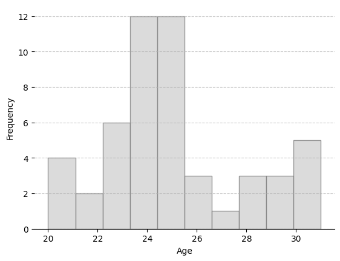

```python
# Histogram
plt.hist(survey_df["Q4"].dropna(), bins=10, edgecolor="Gray", color="lightgray", alpha=0.8)

plt.title("")
plt.xlabel("Age")
plt.ylabel("Frequency")
plt.grid(axis="y", linestyle="--", alpha=0.7)
ax = plt.gca()
ax.spines['top'].set_visible(False)
ax.spines['right'].set_visible(False)
ax.spines['left'].set_visible(False)
```

- sex

```python
gender_map = {"1": "Male", "2": "Female", "3": "Non-binary / third gender", "4":"Prefer not to say", "5":'prefer to self-describe'}
survey_df["Q7_category"] = survey_df["Q7"].map(gender_map)
survey_df["Q7_category"].value_counts()
```

```
Female                       39
Male                         10
Non-binary / third gender     3
Name: Q7_category, dtype: int64
```

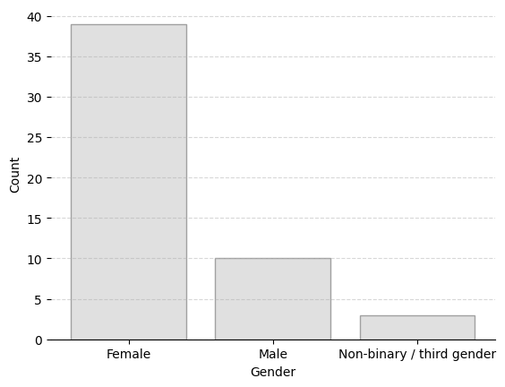

```python
gender_counts = {"Female": 39, "Male": 10, "Non-binary / third gender": 3}
plt.bar(gender_counts.keys(), gender_counts.values(), color='lightgray', edgecolor="gray", alpha=0.7)

plt.title("")
plt.xlabel("Gender")
plt.ylabel("Count")
plt.grid(axis='y', linestyle="--", alpha=0.5)
ax = plt.gca()
ax.spines['top'].set_visible(False)
ax.spines['right'].set_visible(False)
ax.spines['left'].set_visible(False)
```

- Race

```python
race_map = { "1": "White or Caucasian", "2": "Black or African American", "3": "American Indian/Native American or Alaska Native", "4": "Asian", "5": "Native Hawaiian or Other Pacific Islander", "6": "Other", "7": "Prefer not to say" }
survey_df["Mapped_Race"] = survey_df["Q8"].map(race_map)
survey_df["Mapped_Race"].value_counts()
```

```
Asian                        39
White or Caucasian           10
Other                         1
Black or African American     1
Name: Mapped_Race, dtype: int64
```

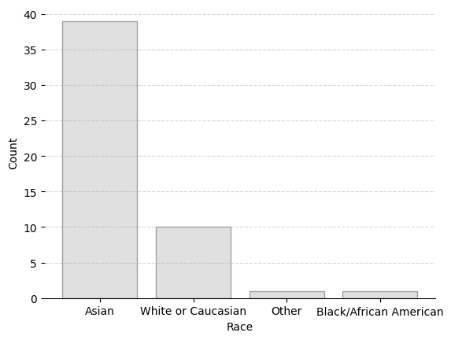

```python
race_counts = {"Asian": 39, "White or Caucasian": 10, "Other": 1, 'Black/African American': 1}
plt.bar(race_counts.keys(), race_counts.values(), color='lightgray', edgecolor="gray", alpha=0.7)

plt.title("")
plt.xlabel("Race")
plt.ylabel("Count")
plt.grid(axis='y', linestyle="--", alpha=0.5)
ax = plt.gca()
ax.spines['top'].set_visible(False)
ax.spines['right'].set_visible(False)
ax.spines['left'].set_visible(False)
```

- Education

```python
Education_map = { "16": "University - Bachelors Degree", "17": "Graduate or professional degree", "15": "Some University but no degree", "18": "Secondary", "5": "Some University but no degree"}
survey_df["Mapped_edu"] = survey_df["Q9"].map(Education_map)
survey_df["Mapped_edu"].value_counts()
```

```
University - Bachelors Degree      40
Graduate or professional degree     7
Some University but no degree       4
Secondary                           1
Name: Mapped_edu, dtype: int64
```

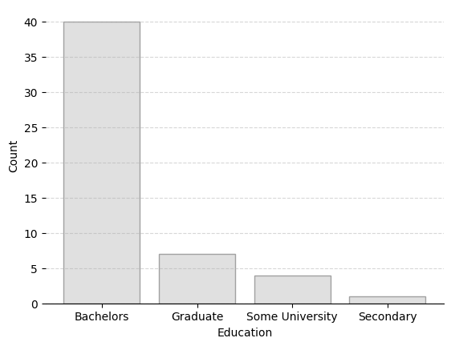

```python
race_counts = {"Bachelors": 40, "Graduate": 7, "Some University": 4, 'Secondary': 1}
plt.bar(race_counts.keys(), race_counts.values(), color='lightgray', edgecolor="gray", alpha=0.7)

plt.title("")
plt.xlabel("Education")
plt.ylabel("Count")
plt.grid(axis='y', linestyle="--", alpha=0.5)
ax = plt.gca()
ax.spines['top'].set_visible(False)
ax.spines['right'].set_visible(False)
ax.spines['left'].set_visible(False)
```

### Step3: RQ1_anlysis

- 1) Have you ever used social media (Instagram, Facebook, X, Reddit, Youtube, etc.)?

```python
mapping = { "1": "No", "2": "Yes"}
RQ1_1= survey_df["Q11"].map(mapping)
RQ1_1.value_counts()
```

```
Yes    48
No      4
Name: Q11, dtype: int64
```

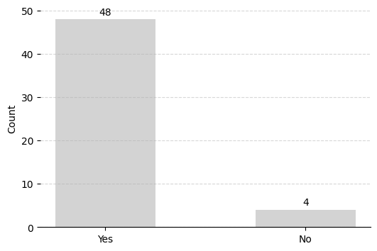

```python
plt.figure(figsize=(6, 4))
plt.bar(RQ1_1.value_counts().index, RQ1_1.value_counts().values, color='lightgray',width=0.5)
plt.xticks(rotation=0)
plt.title("")
plt.xlabel("")
plt.ylabel("Count")
plt.grid(axis='y', linestyle="--", alpha=0.5)
for i, value in enumerate(RQ1_1.value_counts().values):
    plt.text(i, value + 1, str(value), ha='center', fontsize=10, color='black')
ax = plt.gca()
ax.spines['top'].set_visible(False)
ax.spines['right'].set_visible(False)
ax.spines['left'].set_visible(False)
```

- 1. How many hours per day do you spend on social media? (Please enter numbers)

```python
survey_df["Q12"].dropna().astype('int').describe()
```

```
count    45.000000
mean      3.800000
std       2.880972
min       1.000000
25%       2.000000
50%       3.000000
75%       4.000000
max      19.000000
Name: Q12, dtype: float64
```

```python
60*0.8
```

```
48.0
```

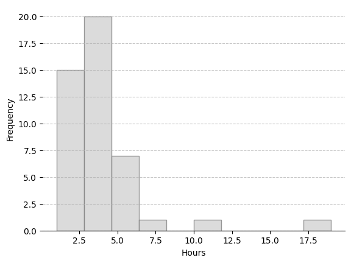

```python
# Histogram
plt.hist(survey_df["Q12"].dropna().astype('int'), bins=10, edgecolor="Gray", color="lightgray", alpha=0.8)

plt.title("")
plt.xlabel("Hours")
plt.ylabel("Frequency")
plt.grid(axis="y", linestyle="--", alpha=0.7)
ax = plt.gca()
ax.spines['top'].set_visible(False)
ax.spines['right'].set_visible(False)
ax.spines['left'].set_visible(False)
```

- 1. Please select all the social media platforms you have used. (Please check all that apply.)

```python
sns = { "1": "Youtube", "2": "Instagram", "3": "Facebook", "4": "Reddit", "5": "X (Twitter)", "6": "Threads", "7": "Tiktok", "8": "Twitch", "9": "Others" }
from collections import Counter
sns_counts = Counter([item for sublist in survey_df["Q13"].dropna().str.split(',') for item in sublist])
sns_mapping_counts = {sns[key]: sns_counts[key] for key in sns_counts}
sns_mapping_counts
```

```
{'Youtube': 47,
 'Instagram': 44,
 'Facebook': 29,
 'Reddit': 10,
 'X (Twitter)': 26,
 'Threads': 9,
 'Tiktok': 7,
 'Twitch': 4,
 'Others': 5}
```

```python
survey_df["Q13_9_TEXT"].dropna()
```

```
10          아프리카TV
11    마스토돈(분산형SNS)
44          Tumblr
45          Tumblr
Name: Q13_9_TEXT, dtype: object
```

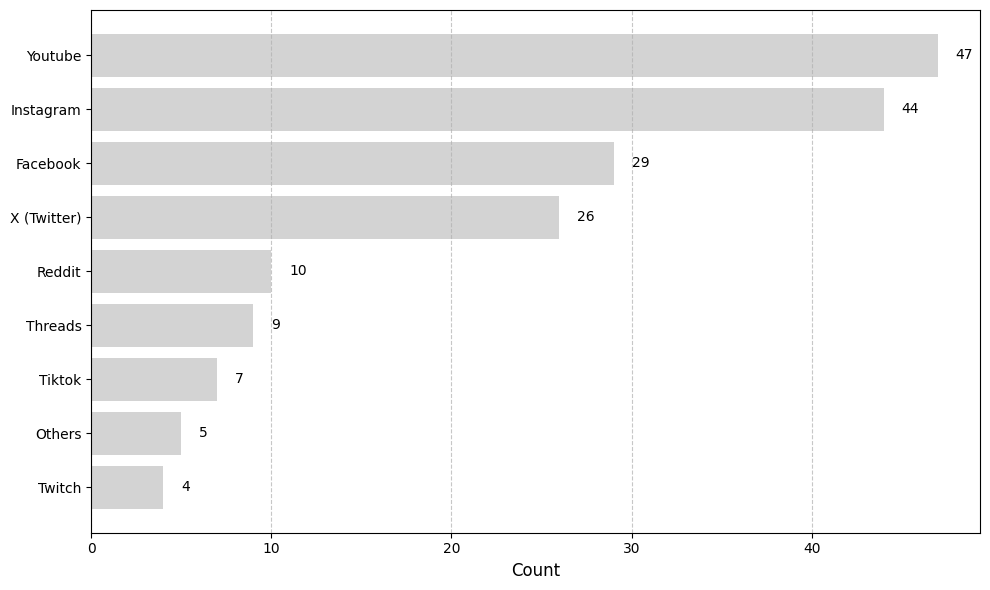

```python
sorted_data = dict(sorted(sns_mapping_counts.items(), key=lambda x: x[1], reverse=False))
platforms = list(sorted_data.keys())  # X
values = list(sorted_data.values())  # Y
plt.figure(figsize=(10, 6))
plt.barh(platforms, values, color='lightgray')  # barh
plt.title('')
plt.xlabel('Count', fontsize=12)
plt.ylabel('', fontsize=12)
plt.grid(axis="x", linestyle="--", alpha=0.7)
for i, value in enumerate(values):
    plt.text(value + 1, i, str(value), va='center', fontsize=10)
plt.tight_layout()  # 레이아웃 조정
```

- 1. Please rank the three social media platforms you selected in order of most frequently used.

```python
Rank_sns = survey_df[['Q14_1','Q14_2','Q14_3','Q14_4','Q14_5','Q14_6','Q14_7','Q14_8','Q14_9']]
Rank_sns.head(5)
```

|  | Q14_1 | Q14_2 | Q14_3 | Q14_4 | Q14_5 | Q14_6 | Q14_7 | Q14_8 | Q14_9 |
| --- | --- | --- | --- | --- | --- | --- | --- | --- | --- |
| 0 | 2 | 1 | NaN | NaN | NaN | NaN | NaN | NaN | NaN |
| 1 | 2 | 1 | 5 | 4 | 7 | 6 | 3 | NaN | NaN |
| 2 | 1 | 2 | 3 | NaN | NaN | NaN | NaN | NaN | NaN |
| 3 | 1 | 2 | NaN | 3 | NaN | NaN | NaN | NaN | NaN |
| 4 | 1 | 2 | 3 | NaN | 4 | NaN | NaN | NaN | NaN |

```python
def reorder_ranks_with_nan(row):
    ordered_values = sorted([(i, val) for i, val in enumerate(row) if not pd.isna(val)], key=lambda x: x[1], reverse=True)
    reordered = [None] * len(row)
    for rank, (original_index, _) in enumerate(ordered_values, start=1):
        reordered[original_index] = rank
    return reordered

reordered_df = Rank_sns.apply(reorder_ranks_with_nan, axis=1, result_type='expand')
reordered_df.columns = Rank_sns.columns
reordered_df.head(5)
```

|  | Q14_1 | Q14_2 | Q14_3 | Q14_4 | Q14_5 | Q14_6 | Q14_7 | Q14_8 | Q14_9 |
| --- | --- | --- | --- | --- | --- | --- | --- | --- | --- |
| 0 | 1.0 | 2.0 | NaN | NaN | NaN | NaN | NaN | NaN | NaN |
| 1 | 6.0 | 7.0 | 3.0 | 4.0 | 1.0 | 2.0 | 5.0 | NaN | NaN |
| 2 | 3.0 | 2.0 | 1.0 | NaN | NaN | NaN | NaN | NaN | NaN |
| 3 | 3.0 | 2.0 | NaN | 1.0 | NaN | NaN | NaN | NaN | NaN |
| 4 | 4.0 | 3.0 | 2.0 | NaN | 1.0 | NaN | NaN | NaN | NaN |

```python
sns_2 = {"Q14_1": "Youtube", "Q14_2": "Instagram", "Q14_3": "Facebook", "Q14_4": "Reddit", "Q14_5": "X (Twitter)", "Q14_6": "Threads", "Q14_7": "Tiktok", "Q14_8": "Twitch", "Q14_9": "Others" }
sns_rankscore = reordered_df.sum(axis=0).rename(index=sns_2)
sns_rankscore
```

```
Youtube        135.0
Instagram      110.0
Facebook        41.0
Reddit          24.0
X (Twitter)     51.0
Threads         21.0
Tiktok          25.0
Twitch           5.0
Others          18.0
dtype: float64
```

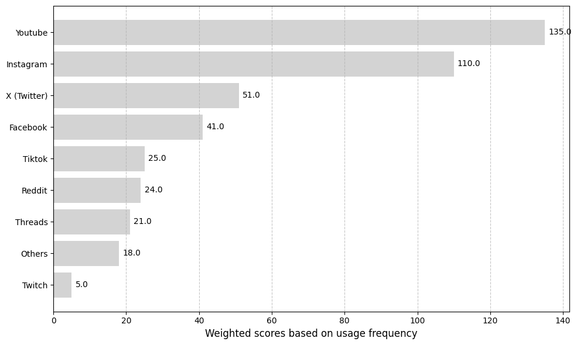

```python
sorted_data = dict(sorted(sns_rankscore.items(), key=lambda x: x[1], reverse=False))
platforms = list(sorted_data.keys())  # X
values = list(sorted_data.values())  # Y
plt.figure(figsize=(10, 6))
plt.barh(platforms, values, color='lightgray')  # barh
plt.title('')
plt.xlabel('Weighted scores based on usage frequency', fontsize=12)
plt.ylabel('', fontsize=12)
plt.grid(axis="x", linestyle="--", alpha=0.7)
for i, value in enumerate(values):
    plt.text(value + 1, i, str(value), va='center', fontsize=10)
plt.tight_layout()  # 레이아웃 조정
```

- 1. Have you ever come across posts, photos, or videos about other people's daily lives on social media?

```python
RQ1_5= survey_df["Q15"].dropna().map(mapping)
RQ1_5.value_counts()
```

```
Yes    47
No      1
Name: Q15, dtype: int64
```

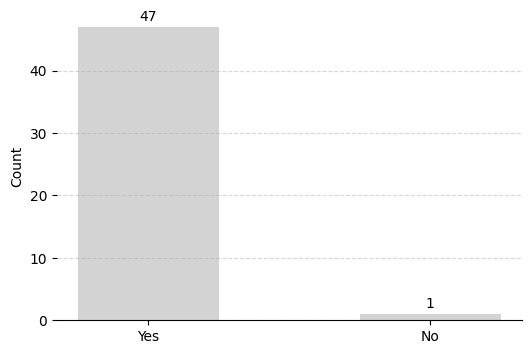

```python
plt.figure(figsize=(6, 4))
plt.bar(RQ1_5.value_counts().index, RQ1_5.value_counts().values, color='lightgray',width=0.5)
plt.xticks(rotation=0)
plt.title("")
plt.xlabel("")
plt.ylabel("Count")
plt.grid(axis='y', linestyle="--", alpha=0.5)
for i, value in enumerate(RQ1_5.value_counts().values):
    plt.text(i, value + 1, str(value), ha='center', fontsize=10, color='black')
ax = plt.gca()
ax.spines['top'].set_visible(False)
ax.spines['right'].set_visible(False)
ax.spines['left'].set_visible(False)
```

- 1. After encountering posts, photos, or videos about other people's daily lives on social media, have you ever experienced negative emotions (e.g., sadness, regret, loneliness, guilt, anger, etc.)?

```python
freq_mapping = {"1": "Never", "2": "Rarely", "3": "Somtimes", "4": "Most of the time", "5": "Always"}
RQ1_6 = survey_df["Q16"].dropna().map(freq_mapping)
RQ1_6.value_counts()
```

```
Somtimes            22
Rarely              12
Never                9
Most of the time     4
Name: Q16, dtype: int64
```

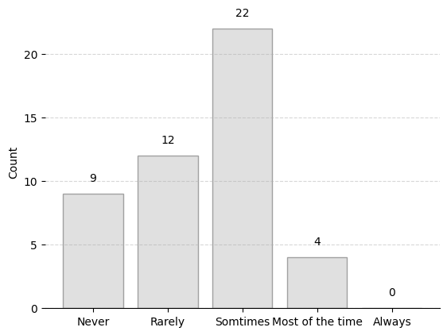

```python
RQ1_6_counts = {"Never": 9, "Rarely": 12, "Somtimes": 22, 'Most of the time': 4, 'Always': 0}
plt.bar(RQ1_6_counts.keys(), RQ1_6_counts.values(), color='lightgray', edgecolor="gray", alpha=0.7)
plt.title("")
plt.xlabel("")
plt.ylabel("Count")
plt.grid(axis='y', linestyle="--", alpha=0.5)
for i, value in enumerate(RQ1_6_counts.values()):
    plt.text(i, value + 1, str(value), ha='center', fontsize=10, color='black')
ax = plt.gca()
ax.spines['top'].set_visible(False)
ax.spines['right'].set_visible(False)
ax.spines['left'].set_visible(False)
```

- 1. What was the content about? (Please check all that apply.)

```python
Content_map = { "1": "Others' successful employment, promotion, or achievements", "2": "Others' luxurious lifestyles", "3": "Others' political opinions", "4": "Others' misfortune or pessimistic attitude", "5": "Others' deliberate provocation", "6": "Posts about gatherings you were not invited to", "7": "Others" }
from collections import Counter
content_counts = Counter([item for sublist in survey_df["Q17"].dropna().str.split(',') for item in sublist])
content_mapping_counts = {Content_map[key]: content_counts[key] for key in content_counts}
content_mapping_counts
```

```
{"Others' successful employment, promotion, or achievements": 17,
 "Others' luxurious lifestyles": 13,
 "Others' political opinions": 18,
 "Others' deliberate provocation": 14,
 "Others' misfortune or pessimistic attitude": 22,
 'Posts about gatherings you were not invited to': 10,
 'Others': 2}
```

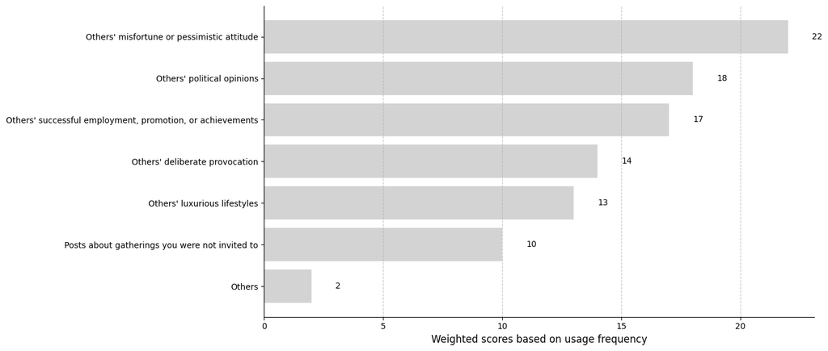

```python
sorted_data = dict(sorted(content_mapping_counts.items(), key=lambda x: x[1], reverse=False))
platforms = list(sorted_data.keys())  # X
values = list(sorted_data.values())  # Y
plt.figure(figsize=(14, 6))
plt.barh(platforms, values, color='lightgray')  # barh
plt.title('')
plt.xlabel('Weighted scores based on usage frequency', fontsize=12)
plt.ylabel('', fontsize=12)
plt.grid(axis="x", linestyle="--", alpha=0.7)
for i, value in enumerate(values):
    plt.text(value + 1, i, str(value), va='center', fontsize=10)
plt.tight_layout()  # 레이아웃 조정
ax = plt.gca()
ax.spines['top'].set_visible(False)
ax.spines['right'].set_visible(False)
```

- 1. What emotion did you feel when encountering the unpleasant contents you selected? (Please check all that apply.)

```python
emotion_mapping = { "1": "Anger", "2": "Sadness", "3": "Fear", "4": "Frustration", "5": "Disgust", "6": "Anxiety", "7": "Loneliness", "8": "Hopelessness", "9": "Jealousy", "10": "Resentment", "11": "Guilt" }
from collections import Counter
emotion_counts = Counter([item for sublist in survey_df["Q18"].dropna().str.split(',') for item in sublist])
emotion_mapping_counts = {emotion_mapping[key]: emotion_counts[key] for key in emotion_counts}
emotion_mapping_counts
```

```
{'Anger': 19,
 'Frustration': 14,
 'Anxiety': 16,
 'Loneliness': 11,
 'Sadness': 15,
 'Disgust': 16,
 'Jealousy': 14,
 'Resentment': 9,
 'Guilt': 5,
 'Hopelessness': 9,
 'Fear': 2}
```

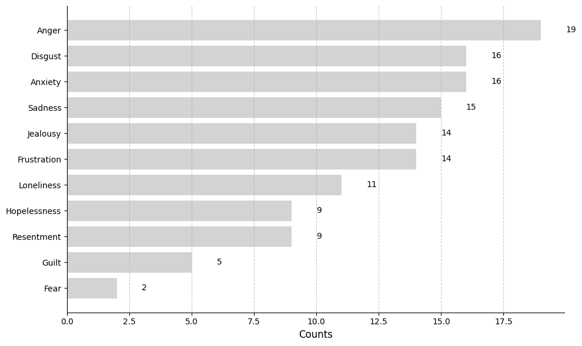

```python
sorted_data = dict(sorted(emotion_mapping_counts.items(), key=lambda x: x[1], reverse=False))
platforms = list(sorted_data.keys())  # X
values = list(sorted_data.values())  # Y
plt.figure(figsize=(10, 6))
plt.barh(platforms, values, color='lightgray')  # barh
plt.title('')
plt.xlabel('Counts', fontsize=12)
plt.ylabel('', fontsize=12)
plt.grid(axis="x", linestyle="--", alpha=0.7)
for i, value in enumerate(values):
    plt.text(value + 1, i, str(value), va='center', fontsize=10)
plt.tight_layout()  # 레이아웃 조정
ax = plt.gca()
ax.spines['top'].set_visible(False)
ax.spines['right'].set_visible(False)
```

- 1. Please rank the emotions you selected in order of most frequently felt.

```python
Rank_emotion = survey_df[['Q19_1','Q19_2','Q19_3','Q19_4','Q19_5','Q19_6','Q19_7','Q19_8','Q19_9', 'Q19_10','Q19_11']]
reordered_df2 = Rank_emotion.apply(reorder_ranks_with_nan, axis=1, result_type='expand')
reordered_df2.columns = Rank_emotion.columns
reordered_df2.head(5)
```

|  | Q19_1 | Q19_2 | Q19_3 | Q19_4 | Q19_5 | Q19_6 | Q19_7 | Q19_8 | Q19_9 | Q19_10 | Q19_11 |
| --- | --- | --- | --- | --- | --- | --- | --- | --- | --- | --- | --- |
| 0 | 2.0 | NaN | NaN | 3.0 | NaN | 1.0 | 4.0 | NaN | NaN | NaN | NaN |
| 1 | 2.0 | NaN | NaN | 1.0 | NaN | 4.0 | 3.0 | NaN | NaN | NaN | NaN |
| 2 | NaN | NaN | NaN | NaN | NaN | NaN | NaN | NaN | NaN | NaN | NaN |
| 3 | NaN | NaN | NaN | NaN | NaN | NaN | NaN | NaN | NaN | NaN | NaN |
| 4 | NaN | 2.0 | NaN | NaN | 1.0 | 3.0 | NaN | NaN | NaN | NaN | NaN |

```python
emotion_2 = { "Q19_1": "Anger", "Q19_2": "Sadness", "Q19_3": "Fear", "Q19_4": "Frustration", "Q19_5": "Disgust", "Q19_6": "Anxiety", "Q19_7": "Loneliness", "Q19_8": "Hopelessness", "Q19_9": "Jealousy", "Q19_10": "Resentment", "Q19_11": "Guilt" }
emotion_rankscore = reordered_df2.sum(axis=0).rename(index=emotion_2)
emotion_rankscore
```

```
Anger           60.0
Sadness         37.0
Fear             5.0
Frustration     38.0
Disgust         34.0
Anxiety         42.0
Loneliness      32.0
Hopelessness    14.0
Jealousy        41.0
Resentment      22.0
Guilt           23.0
dtype: float64
```

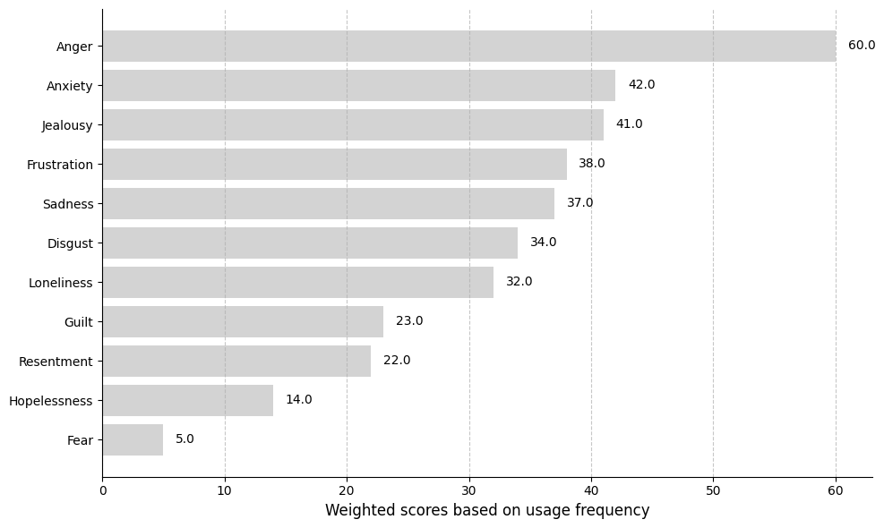

```python
sorted_data = dict(sorted(emotion_rankscore.items(), key=lambda x: x[1], reverse=False))
platforms = list(sorted_data.keys())  # X
values = list(sorted_data.values())  # Y
plt.figure(figsize=(10, 6))
plt.barh(platforms, values, color='lightgray')  # barh
plt.title('')
plt.xlabel('Weighted scores based on usage frequency', fontsize=12)
plt.ylabel('', fontsize=12)
plt.grid(axis="x", linestyle="--", alpha=0.7)
for i, value in enumerate(values):
    plt.text(value + 1, i, str(value), va='center', fontsize=10)
plt.tight_layout()  # 레이아웃 조정
ax = plt.gca()
ax.spines['top'].set_visible(False)
ax.spines['right'].set_visible(False)
```

- 1. How much did the contents affect your negative emotions?

```python
df10 = survey_df[['Q20_1','Q20_2','Q20_3','Q20_4','Q20_5','Q20_6','Q20_7']]
mean_dict = {}
for column in df10.columns:
    mean_value = df10[column].dropna().astype(int).mean(axis=0).round(2)
    mean_dict[column] = mean_value
Q20mapping = { "Q20_1": "Others' successful employment, promotion, or achievements", "Q20_2": "Others' luxurious lifestyles", "Q20_3": "Others' political opinions", "Q20_4": "Others' misfortune or pessimistic attitude", "Q20_5": "Others' deliberate provocation", "Q20_6": "Posts about gatherings you were not invited to", "Q20_7": "Others" }
mapped_mean_dict = {Q20mapping[key]: value for key, value in mean_dict.items()}
```

```python
mapped_mean_dict
```

```
{"Others' successful employment, promotion, or achievements": 3.35,
 "Others' luxurious lifestyles": 3.46,
 "Others' political opinions": 3.61,
 "Others' misfortune or pessimistic attitude": 3.23,
 "Others' deliberate provocation": 3.57,
 'Posts about gatherings you were not invited to': 2.8,
 'Others': 2.5}
```

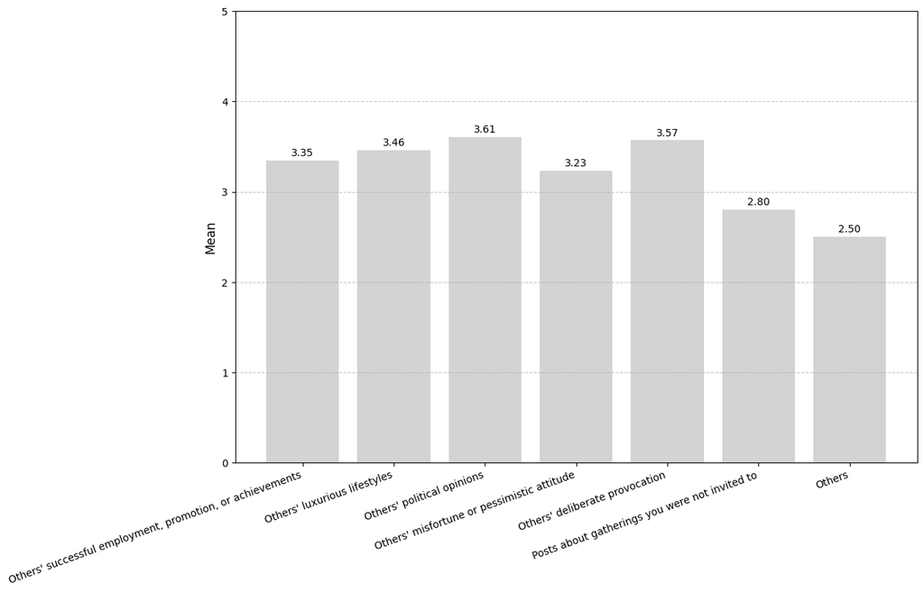

```python
categories = list(mapped_mean_dict.keys())
values = list(mapped_mean_dict.values())
plt.figure(figsize=(12, 8))
plt.bar(categories, values, color='lightgray')
plt.title('')
plt.ylabel('Mean', fontsize=12)
plt.xlabel('', fontsize=12)
plt.xticks(rotation=20, ha='right', fontsize=10)  # 레이블 각도와 정렬
plt.yticks(fontsize=10)
plt.ylim(0, 5)
plt.grid(axis="y", linestyle="--", alpha=0.7)
for i, value in enumerate(values):
    plt.text(i, value + 0.05, f"{value:.2f}", ha='center', fontsize=10)
ax.spines['top'].set_visible(False)
ax.spines['right'].set_visible(False)
```

- 1. How do the emotions you experience from social media content affect your daily life?

```python
pos_neg_mapping = { "1": "Extremely negative", "2": "Somewhat negative", "3": "Neutral", "4": "Somewhat positive", "5": "Extremely positive" }
survey_df["Q21"].map(pos_neg_mapping).value_counts()
```

```
Neutral              19
Somewhat negative    14
Somewhat positive     5
Name: Q21, dtype: int64
```

[figure not shown]

```python
RQ1_11_counts = {"Extremely negative": 0, "Somewhat negative": 14, "Neutral": 19, 'Somewhat positive': 5, 'Extremely positive': 0}
plt.bar(RQ1_11_counts.keys(), RQ1_6_counts.values(), color='lightgray', edgecolor="gray", alpha=0.7)
plt.title("")
plt.xlabel("")
plt.ylabel("")
plt.grid(axis='y', linestyle="--", alpha=0.5)
plt.xticks(fontsize=6)
plt.yticks([])
for i, value in enumerate(RQ1_11_counts.values()):
    plt.text(i, value + 1, str(value), ha='center', fontsize=10, color='black')
ax = plt.gca()
ax.spines['top'].set_visible(False)
ax.spines['right'].set_visible(False)
ax.spines['left'].set_visible(False)
```

- evaluation

Has this influenced whether or not you use social media?

```python
yes_no_mapping = { "1": "Definitely not", "2": "Probably not", "3": "Might or might not", "4": "Probably yes", "5": "Definitely yes" }
eval_1 = survey_df["Q22"].map(yes_no_mapping).value_counts()
eval_1
```

```
Probably yes          13
Probably not          12
Might or might not     5
Definitely yes         4
Definitely not         4
Name: Q22, dtype: int64
```

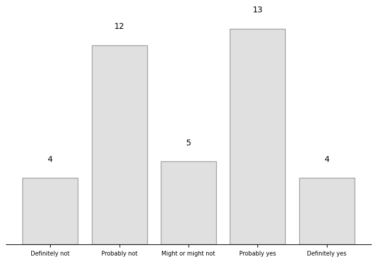

```python
ordered_labels = ["Definitely not", "Probably not", "Might or might not", "Probably yes", "Definitely yes"]
ordered_data = {label: eval_1[label] for label in ordered_labels}
categories = list(ordered_data.keys())
values = list(ordered_data.values())
plt.figure(figsize=(8, 5))  # 가로 8, 세로 5 크기
plt.bar(categories, values,  color='lightgray', edgecolor="gray", alpha=0.7)

plt.xlabel("")
plt.ylabel("")
plt.grid(axis='y', linestyle="--", alpha=0.5)
plt.xticks(fontsize=7)
plt.yticks([])
for i, value in enumerate(ordered_data.values()):
    plt.text(i, value + 1, str(value), ha='center', fontsize=10, color='black')
ax = plt.gca()
ax.spines['top'].set_visible(False)
ax.spines['right'].set_visible(False)
ax.spines['left'].set_visible(False)
```

```python
eval_2 = survey_df["Q23"].map(yes_no_mapping).value_counts()
eval_2
```

```
Probably not          16
Probably yes           7
Might or might not     6
Definitely yes         5
Definitely not         4
Name: Q23, dtype: int64
```

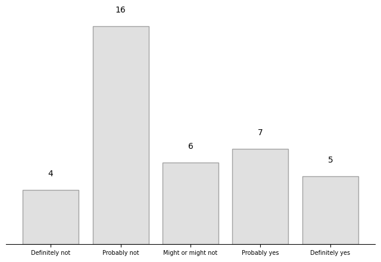

```python
ordered_labels = ["Definitely not", "Probably not", "Might or might not", "Probably yes", "Definitely yes"]
ordered_data = {label: eval_2[label] for label in ordered_labels}
categories = list(ordered_data.keys())
values = list(ordered_data.values())
plt.figure(figsize=(8, 5))  # 가로 8, 세로 5 크기
plt.bar(categories, values,  color='lightgray', edgecolor="gray", alpha=0.7)

plt.xlabel("")
plt.ylabel("")
plt.grid(axis='y', linestyle="--", alpha=0.5)
plt.xticks(fontsize=7)
plt.yticks([])
for i, value in enumerate(ordered_data.values()):
    plt.text(i, value + 1, str(value), ha='center', fontsize=10, color='black')
ax = plt.gca()
ax.spines['top'].set_visible(False)
ax.spines['right'].set_visible(False)
ax.spines['left'].set_visible(False)
```

```python
safe_unsafe_mapping = { "1": "Definitely unsafe", "2": "Probably unsafe", "3": "Might or might not", "4": "Probably safe", "5": "Definitely safe" }
```

```python
eval_3 = survey_df["Q24"].map(safe_unsafe_mapping).value_counts()
eval_3['Definitely safe'] = 0
eval_3
```

```
Might or might not    18
Probably unsafe       11
Probably safe          5
Definitely unsafe      4
Definitely safe        0
Name: Q24, dtype: int64
```

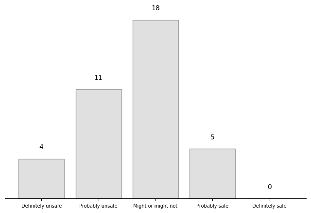

```python
ordered_labels = ["Definitely unsafe", "Probably unsafe", "Might or might not", "Probably safe", "Definitely safe"]
ordered_data = {label: eval_3[label] for label in ordered_labels}
categories = list(ordered_data.keys())
values = list(ordered_data.values())
plt.figure(figsize=(8, 5))  # 가로 8, 세로 5 크기
plt.bar(categories, values,  color='lightgray', edgecolor="gray", alpha=0.7)

plt.xlabel("")
plt.ylabel("")
plt.grid(axis='y', linestyle="--", alpha=0.5)
plt.xticks(fontsize=7)
plt.yticks([])
for i, value in enumerate(ordered_data.values()):
    plt.text(i, value + 1, str(value), ha='center', fontsize=10, color='black')
ax = plt.gca()
ax.spines['top'].set_visible(False)
ax.spines['right'].set_visible(False)
ax.spines['left'].set_visible(False)
```

### Step 4: RQ2

- 1. Have you ever encountered content recommended by algorithms (e.g., YouTube Shorts, Instagram Reels)?

```python
RQ2_1= survey_df["Q25"].map(mapping).value_counts()
RQ2_1
```

```
Yes    45
No      3
Name: Q25, dtype: int64
```

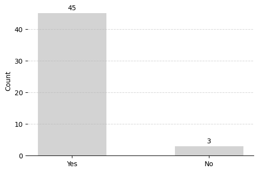

```python
plt.figure(figsize=(6, 4))
plt.bar(RQ2_1.index, RQ2_1.values, color='lightgray',width=0.5)
plt.xticks(rotation=0)
plt.title("")
plt.xlabel("")
plt.ylabel("Count")
plt.grid(axis='y', linestyle="--", alpha=0.5)
for i, value in enumerate(RQ2_1.values):
    plt.text(i, value + 1, str(value), ha='center', fontsize=10, color='black')
ax = plt.gca()
ax.spines['top'].set_visible(False)
ax.spines['right'].set_visible(False)
ax.spines['left'].set_visible(False)
```

- 1. Have you incidentally encountered unpleasant content recommended by an algorithm?

```python
freq_mapping = {"1": "Never", "2": "Rarely", "3": "Somtimes", "4": "Most of the time", "5": "Always"}
RQ2_2= survey_df["Q26"].map(freq_mapping).value_counts()
RQ2_2
```

```
Somtimes            22
Rarely              11
Most of the time     7
Always               3
Never                2
Name: Q26, dtype: int64
```

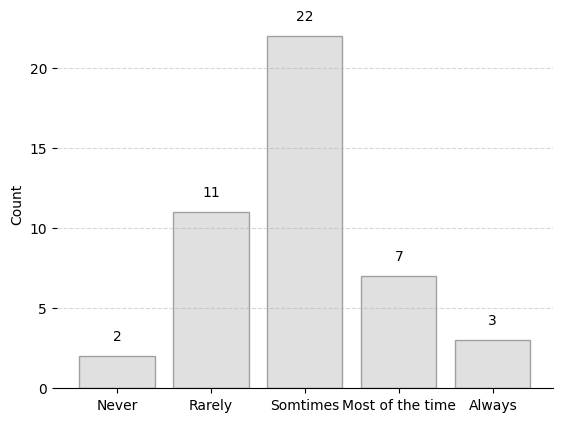

```python
RQ1_6_counts = {"Never": 2, "Rarely": 11, "Somtimes": 22, 'Most of the time': 7, 'Always': 3}
plt.bar(RQ1_6_counts.keys(), RQ1_6_counts.values(), color='lightgray', edgecolor="gray", alpha=0.7)
plt.title("")
plt.xlabel("")
plt.ylabel("Count")
plt.grid(axis='y', linestyle="--", alpha=0.5)
for i, value in enumerate(RQ1_6_counts.values()):
    plt.text(i, value + 1, str(value), ha='center', fontsize=10, color='black')
ax = plt.gca()
ax.spines['top'].set_visible(False)
ax.spines['right'].set_visible(False)
ax.spines['left'].set_visible(False)
```

- 1. What was the content about? (Please check all that apply.)

```python
Content_map = mapping = { "1": "Violent language or behavior", "2": "Sexually explicit content", "3": "Inappropriate advertisements", "4": "Use of addictive substances (e.g. tobacco, alcohol, or drugs)", "5": "Crime scene", "6": "Political propaganda", "7": "Cultural or religious insults", "8": "Misinformation, Disinformation, or Fake news", "9": "Triggering trauma (e.g., shocking incidents, disasters, or death)", "10": "Defamation or privacy invasion", "11": "Others" }
from collections import Counter
content_counts = Counter([item for sublist in survey_df["Q27"].dropna().str.split(',') for item in sublist])
content_mapping_counts = {Content_map[key]: content_counts[key] for key in content_counts}
content_mapping_counts
```

```
{'Political propaganda': 21,
 'Misinformation, Disinformation, or Fake news': 28,
 'Violent language or behavior': 17,
 'Inappropriate advertisements': 27,
 'Triggering trauma (e.g., shocking incidents, disasters, or death)': 9,
 'Crime scene': 7,
 'Defamation or privacy invasion': 8,
 'Sexually explicit content': 18,
 'Cultural or religious insults': 6,
 'Use of addictive substances (e.g. tobacco, alcohol, or drugs)': 3}
```

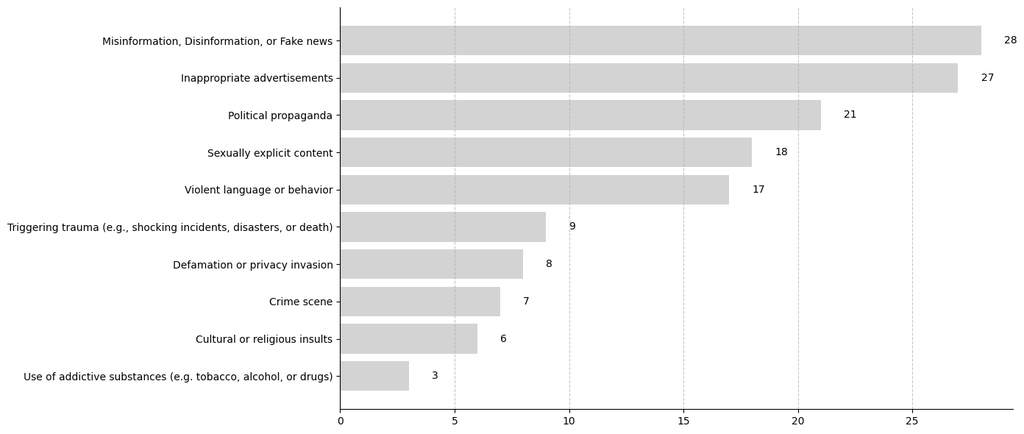

```python
sorted_data = dict(sorted(content_mapping_counts.items(), key=lambda x: x[1], reverse=False))
platforms = list(sorted_data.keys())  # X
values = list(sorted_data.values())  # Y
plt.figure(figsize=(14, 6))
plt.barh(platforms, values, color='lightgray')  # barh
plt.title('')
plt.xlabel('', fontsize=12)
plt.ylabel('', fontsize=12)
plt.grid(axis="x", linestyle="--", alpha=0.7)
for i, value in enumerate(values):
    plt.text(value + 1, i, str(value), va='center', fontsize=10)
plt.tight_layout()  # 레이아웃 조정
ax = plt.gca()
ax.spines['top'].set_visible(False)
ax.spines['right'].set_visible(False)
```

- 1. What emotion did you feel when encountering the unpleasant contents you selected? (Please check all that apply.)

```python
emotion_mapping = { "1": "Anger", "2": "Sadness", "3": "Fear", "4": "Frustration", "5": "Disgust", "6": "Anxiety", "7": "Loneliness", "8": "Hopelessness", "9": "Jealousy", "10": "Resentment", "11": "Guilt" }
from collections import Counter
emotion_counts = Counter([item for sublist in survey_df["Q28"].dropna().str.split(',') for item in sublist])
emotion_mapping_counts = {emotion_mapping[key]: emotion_counts[key] for key in emotion_counts}
emotion_mapping_counts
```

```
{'Anger': 31,
 'Frustration': 9,
 'Fear': 9,
 'Disgust': 30,
 'Resentment': 18,
 'Sadness': 6,
 'Anxiety': 11,
 'Jealousy': 1,
 'Guilt': 1,
 'Hopelessness': 2}
```

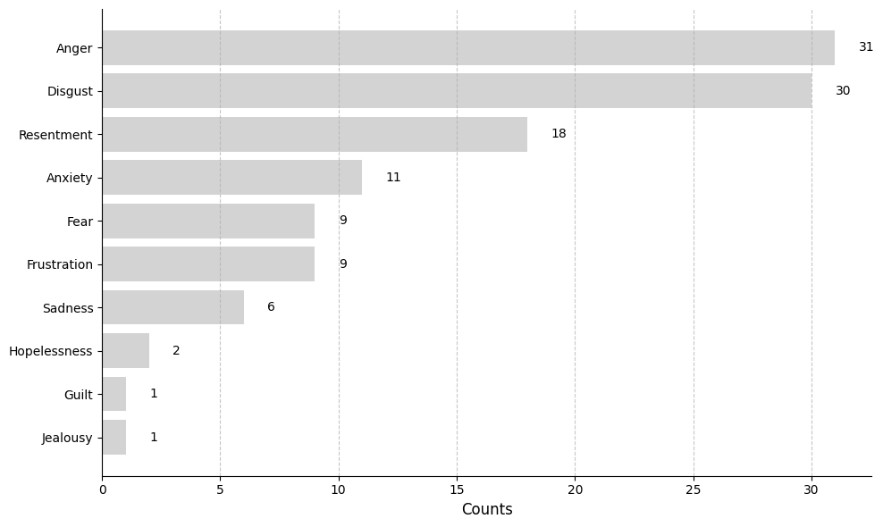

```python
sorted_data = dict(sorted(emotion_mapping_counts.items(), key=lambda x: x[1], reverse=False))
platforms = list(sorted_data.keys())  # X
values = list(sorted_data.values())  # Y
plt.figure(figsize=(10, 6))
plt.barh(platforms, values, color='lightgray')  # barh
plt.title('')
plt.xlabel('Counts', fontsize=12)
plt.ylabel('', fontsize=12)
plt.grid(axis="x", linestyle="--", alpha=0.7)
for i, value in enumerate(values):
    plt.text(value + 1, i, str(value), va='center', fontsize=10)
plt.tight_layout()  # 레이아웃 조정
ax = plt.gca()
ax.spines['top'].set_visible(False)
ax.spines['right'].set_visible(False)
```

- 1. Please rank the emotions you selected in order of most frequently felt.

```python
Rank_emotion = survey_df[['Q29_1','Q29_2','Q29_3','Q29_4','Q29_5','Q29_6','Q29_7','Q29_8','Q29_9','Q29_10','Q29_11']]
reordered_df4 = Rank_emotion.apply(reorder_ranks_with_nan, axis=1, result_type='expand')
reordered_df4.columns = Rank_emotion.columns
reordered_df4.head(5)
```

|  | Q29_1 | Q29_2 | Q29_3 | Q29_4 | Q29_5 | Q29_6 | Q29_7 | Q29_8 | Q29_9 | Q29_10 | Q29_11 |
| --- | --- | --- | --- | --- | --- | --- | --- | --- | --- | --- | --- |
| 0 | 1.0 | NaN | NaN | 2.0 | NaN | NaN | NaN | NaN | NaN | NaN | NaN |
| 1 | 1.0 | NaN | 3.0 | NaN | 2.0 | NaN | NaN | NaN | NaN | 4.0 | NaN |
| 2 | 2.0 | NaN | 1.0 | NaN | 3.0 | NaN | NaN | NaN | NaN | NaN | NaN |
| 3 | 2.0 | NaN | NaN | NaN | 1.0 | NaN | NaN | NaN | NaN | NaN | NaN |
| 4 | 3.0 | 4.0 | NaN | NaN | 5.0 | 1.0 | NaN | NaN | NaN | 2.0 | NaN |

```python
emotion_2 = { "Q29_1": "Anger", "Q29_2": "Sadness", "Q29_3": "Fear", "Q29_4": "Frustration", "Q29_5": "Disgust", "Q29_6": "Anxiety", "Q29_7": "Loneliness", "Q29_8": "Hopelessness", "Q29_9": "Jealousy", "Q29_10": "Resentment", "Q29_11": "Guilt" }
emotion_rankscore = reordered_df4.sum(axis=0).rename(index=emotion_2)
emotion_rankscore
```

```
Anger           58.0
Sadness         17.0
Fear            22.0
Frustration     25.0
Disgust         54.0
Anxiety         20.0
Loneliness       0.0
Hopelessness     2.0
Jealousy         2.0
Resentment      39.0
Guilt            1.0
dtype: float64
```

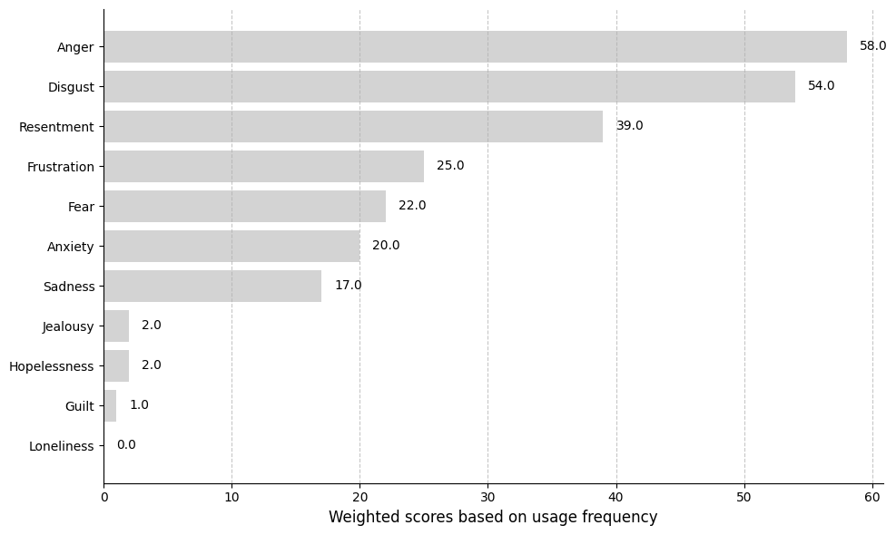

```python
sorted_data = dict(sorted(emotion_rankscore.items(), key=lambda x: x[1], reverse=False))
platforms = list(sorted_data.keys())  # X
values = list(sorted_data.values())  # Y
plt.figure(figsize=(10, 6))
plt.barh(platforms, values, color='lightgray')  # barh
plt.title('')
plt.xlabel('Weighted scores based on usage frequency', fontsize=12)
plt.ylabel('', fontsize=12)
plt.grid(axis="x", linestyle="--", alpha=0.7)
for i, value in enumerate(values):
    plt.text(value + 1, i, str(value), va='center', fontsize=10)
plt.tight_layout()  # 레이아웃 조정
ax = plt.gca()
ax.spines['top'].set_visible(False)
ax.spines['right'].set_visible(False)
```

- 6.How much did the contents affect your negative emotions?

```python
df30 = survey_df[['Q30_1','Q30_2','Q30_3','Q30_4','Q30_5','Q30_6','Q30_7','Q30_8','Q30_9','Q30_10','Q30_11']]
mean_dict = {}
for column in df30.columns:
    mean_value = df30[column].dropna().astype(float).mean(axis=0)
    mean_dict[column] = mean_value
Q30mapping = Content_map = { "Q30_1": "Violent language or behavior", "Q30_2": "Sexually explicit content", "Q30_3": "Inappropriate advertisements", "Q30_4": "Use of addictive substances (e.g. tobacco, alcohol, or drugs)", "Q30_5": "Crime scene", "Q30_6": "Political propaganda", "Q30_7": "Cultural or religious insults", "Q30_8": "Misinformation, Disinformation, or Fake news", "Q30_9": "Triggering trauma (e.g., shocking incidents, disasters, or death)", "Q30_10": "Defamation or privacy invasion", "Q30_11": "Others" }
mapped_mean_dict = {Q30mapping[key]: value for key, value in mean_dict.items()}

import math
rounded_dict = {key: round(value, 2) for key, value in mapped_mean_dict.items() if not math.isnan(value)}
```

```python
rounded_dict
```

```
{'Violent language or behavior': 3.94,
 'Sexually explicit content': 3.75,
 'Inappropriate advertisements': 3.16,
 'Use of addictive substances (e.g. tobacco, alcohol, or drugs)': 2.0,
 'Crime scene': 3.71,
 'Political propaganda': 3.43,
 'Cultural or religious insults': 3.6,
 'Misinformation, Disinformation, or Fake news': 3.68,
 'Triggering trauma (e.g., shocking incidents, disasters, or death)': 3.78,
 'Defamation or privacy invasion': 3.38}
```

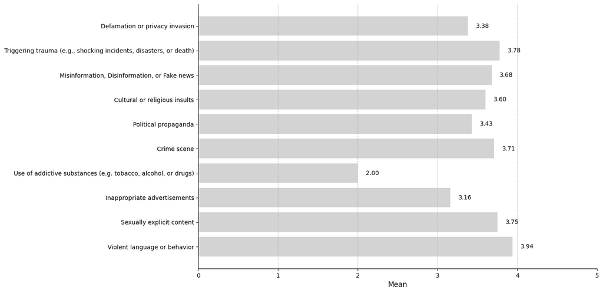

```python
categories = list(rounded_dict.keys())
values = list(rounded_dict.values())
plt.figure(figsize=(12, 8))
plt.barh(categories, values, color='lightgray')

plt.title('', fontsize=16)
plt.xlabel('Mean', fontsize=12)  # X축 레이블
plt.ylabel('', fontsize=12)  # Y축 레이블은 빈 상태로 둠

plt.xticks(fontsize=10)
plt.yticks(fontsize=10)
plt.xlim(0, 5)
plt.grid(axis="x", linestyle="--", alpha=0.7)
for i, value in enumerate(values):
    plt.text(value + 0.1, i, f"{value:.2f}", va='center', fontsize=10)  # 막대 오른쪽에 값 표시
ax = plt.gca()
ax.spines['top'].set_visible(False)
ax.spines['right'].set_visible(False)
```

- 1. How do social media contents that provoke unpleasant emotions influence you—prompting you to ignore the information, or encouraging you to seek it further?

```python
df31 = survey_df[['Q31_1','Q31_2','Q31_3','Q31_4','Q31_5','Q31_6','Q31_7','Q31_8','Q31_9','Q31_10','Q31_11']]
mean_dict = {}
for column in df31.columns:
    mean_value = df30[column].dropna().astype(float).mean(axis=0)
    mean_dict[column] = mean_value
Q31mapping = Content_map = { "Q31_1": "Violent language or behavior", "Q31_2": "Sexually explicit content", "Q31_3": "Inappropriate advertisements", "Q31_4": "Use of addictive substances (e.g. tobacco, alcohol, or drugs)", "Q31_5": "Crime scene", "Q31_6": "Political propaganda", "Q31_7": "Cultural or religious insults", "Q31_8": "Misinformation, Disinformation, or Fake news", "Q31_9": "Triggering trauma (e.g., shocking incidents, disasters, or death)", "Q31_10": "Defamation or privacy invasion", "Q31_11": "Others" }
mapped_mean_dict = {Q31mapping[key]: value for key, value in mean_dict.items()}
rounded_dict = {key: round(value, 2) for key, value in mapped_mean_dict.items() if not math.isnan(value)}
rounded_dict
```

[output not shown]

[figure not shown]

```python
categories = list(rounded_dict.keys())
values = list(rounded_dict.values())
plt.figure(figsize=(12, 8))
plt.bar(categories, values, color='lightgray')
plt.title('')
plt.ylabel('Mean', fontsize=12)
plt.xlabel('', fontsize=12)
plt.xticks(rotation=20, ha='right', fontsize=10)  # 레이블 각도와 정렬
plt.yticks(fontsize=10)
plt.ylim(0, 5)
plt.grid(axis="y", linestyle="--", alpha=0.7)
for i, value in enumerate(values):
    plt.text(i, value + 0.05, f"{value:.2f}", ha='center', fontsize=10)
ax.spines['top'].set_visible(False)
ax.spines['right'].set_visible(False)
```

- 1. When you encounter unpleasant contents, do you usually report to the algorithm as "Do not recommend this type of contents"?

```python
freq_mapping = {"8": "Never", "9": "Somtimes", "10": "About half the time", "11": "Most of the time", "12": "Always"}
RQ2_8 = survey_df["Q32"].dropna().map(freq_mapping)
RQ2_8.value_counts()
```

```
Most of the time       12
About half the time    12
Somtimes               10
Always                  8
Never                   1
Name: Q32, dtype: int64
```

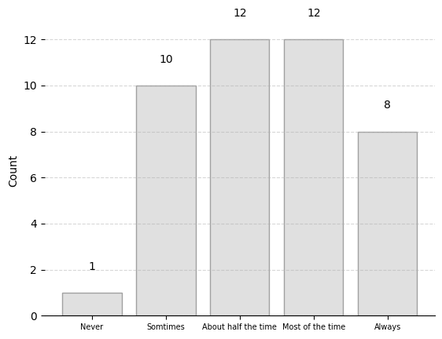

```python
counts = {"Never": 1,  "Somtimes": 10, "About half the time": 12,'Most of the time': 12, 'Always': 8}
plt.bar(counts.keys(), counts.values(), color='lightgray', edgecolor="gray", alpha=0.7)
plt.title("")
plt.xlabel("")
plt.ylabel("Count")
plt.xticks(fontsize=7)
plt.grid(axis='y', linestyle="--", alpha=0.5)
for i, value in enumerate(counts.values()):
    plt.text(i, value + 1, str(value), ha='center', fontsize=10, color='black')
ax = plt.gca()
ax.spines['top'].set_visible(False)
ax.spines['right'].set_visible(False)
ax.spines['left'].set_visible(False)
```

- 1. Have you ever experienced an algorithm repeatedly recommending the unpleasant contents despite reporting it as "Not recommend this type of content"?

```python
mapping = { "1": "No", "2": "Yes"}
RQ2_9= survey_df["Q33"].map(mapping)
RQ2_9.value_counts()
```

```
Yes    28
No     14
Name: Q33, dtype: int64
```

[figure not shown]

```python
plt.figure(figsize=(6, 4))
plt.bar(RQ2_9.value_counts().index, RQ2_9.value_counts().values, color='lightgray',width=0.5)
plt.xticks(rotation=0)
plt.title("")
plt.xlabel("")
plt.ylabel("Count")
plt.grid(axis='y', linestyle="--", alpha=0.5)
for i, value in enumerate(RQ1_1.value_counts().values):
    plt.text(i, value + 1, str(value), ha='center', fontsize=10, color='black')
ax = plt.gca()
ax.spines['top'].set_visible(False)
ax.spines['right'].set_visible(False)
ax.spines['left'].set_visible(False)
```

**Evaluation**

- Has this influenced whether or not you use social media?

```python
yes_no_mapping = { "1": "Definitely not", "2": "Probably not", "3": "Might or might not", "4": "Probably yes", "5": "Definitely yes" }
eval_1 = survey_df["Q34"].map(yes_no_mapping).value_counts()
eval_1
```

```
Probably not          22
Might or might not     8
Probably yes           7
Definitely not         6
Definitely yes         2
Name: Q34, dtype: int64
```

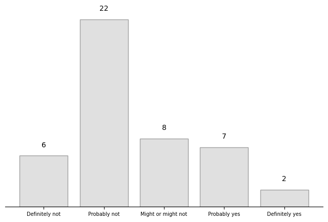

```python
ordered_labels = ["Definitely not", "Probably not", "Might or might not", "Probably yes", "Definitely yes"]
ordered_data = {label: eval_1[label] for label in ordered_labels}
categories = list(ordered_data.keys())
values = list(ordered_data.values())
plt.figure(figsize=(8, 5))  # 가로 8, 세로 5 크기
plt.bar(categories, values,  color='lightgray', edgecolor="gray", alpha=0.7)

plt.xlabel("")
plt.ylabel("")
plt.grid(axis='y', linestyle="--", alpha=0.5)
plt.xticks(fontsize=7)
plt.yticks([])
for i, value in enumerate(ordered_data.values()):
    plt.text(i, value + 1, str(value), ha='center', fontsize=10, color='black')
ax = plt.gca()
ax.spines['top'].set_visible(False)
ax.spines['right'].set_visible(False)
ax.spines['left'].set_visible(False)
```

- Has this influenced the amount of time you spend on social media?

```python
eval_2 = survey_df["Q35"].map(yes_no_mapping).value_counts()
eval_2
```

```
Probably not          18
Definitely not        11
Probably yes           9
Might or might not     6
Definitely yes         1
Name: Q35, dtype: int64
```

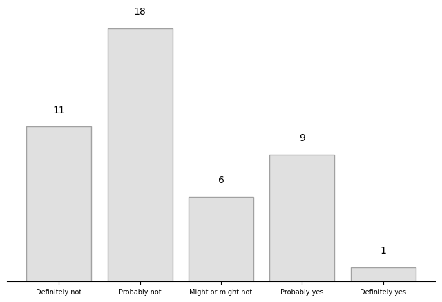

```python
ordered_labels = ["Definitely not", "Probably not", "Might or might not", "Probably yes", "Definitely yes"]
ordered_data = {label: eval_2[label] for label in ordered_labels}
categories = list(ordered_data.keys())
values = list(ordered_data.values())
plt.figure(figsize=(8, 5))  # 가로 8, 세로 5 크기
plt.bar(categories, values,  color='lightgray', edgecolor="gray", alpha=0.7)

plt.xlabel("")
plt.ylabel("")
plt.grid(axis='y', linestyle="--", alpha=0.5)
plt.xticks(fontsize=7)
plt.yticks([])
for i, value in enumerate(ordered_data.values()):
    plt.text(i, value + 1, str(value), ha='center', fontsize=10, color='black')
ax = plt.gca()
ax.spines['top'].set_visible(False)
ax.spines['right'].set_visible(False)
ax.spines['left'].set_visible(False)
```

```python
safe_unsafe_mapping = { "1": "Definitely unsafe", "2": "Probably unsafe", "3": "Might or might not", "4": "Probably safe", "5": "Definitely safe" }
```

```python
eval_3 = survey_df["Q34"].map(safe_unsafe_mapping).value_counts()
eval_3['Definitely safe'] = 0
eval_3
```

```
Probably unsafe       22
Might or might not     8
Probably safe          7
Definitely unsafe      6
Definitely safe        0
Name: Q34, dtype: int64
```

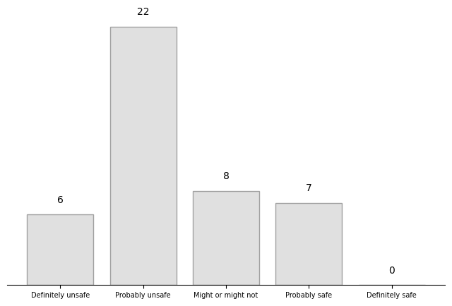

```python
ordered_labels = ["Definitely unsafe", "Probably unsafe", "Might or might not", "Probably safe", "Definitely safe"]
ordered_data = {label: eval_3[label] for label in ordered_labels}
categories = list(ordered_data.keys())
values = list(ordered_data.values())
plt.figure(figsize=(8, 5))  # 가로 8, 세로 5 크기
plt.bar(categories, values,  color='lightgray', edgecolor="gray", alpha=0.7)

plt.xlabel("")
plt.ylabel("")
plt.grid(axis='y', linestyle="--", alpha=0.5)
plt.xticks(fontsize=7)
plt.yticks([])
for i, value in enumerate(ordered_data.values()):
    plt.text(i, value + 1, str(value), ha='center', fontsize=10, color='black')
ax = plt.gca()
ax.spines['top'].set_visible(False)
ax.spines['right'].set_visible(False)
ax.spines['left'].set_visible(False)
```